DRA: მეექვსე შეხვედრა

# შესავალი მონაცემთა ვიზუალიზაციაში

დავით სიჭინავა, CRRC-საქართველო | თსუ  
27 აპრილი, 2018

### დღევანდელი გეგმა:

- (მოკლე) შესავალი მონაცემთა ვიზუალიზაციაში;
- ვიზუალიზაციის ,,ფენოვანი" გრამატიკა;
- `ggplot2` ბიბლიოთეკა;
- პრაქტიკული სამუშაოები;

### სანამ დავიწყებდეთ:

- დავრწმუნდეთ, რომ ყველა თქვენგანს ჩამოტვირთული აქვს `ggplot2` ბიბლიოთეკა
- მიუთითეთ სამუშაო დირექტორია (კარგი პრაქტიკა)

### სანამ დავიწყებდეთ:

```r
library(ggplot2)
```

### (მოკლე) შესავალი მონაცემთა ვიზუალიზაციაში

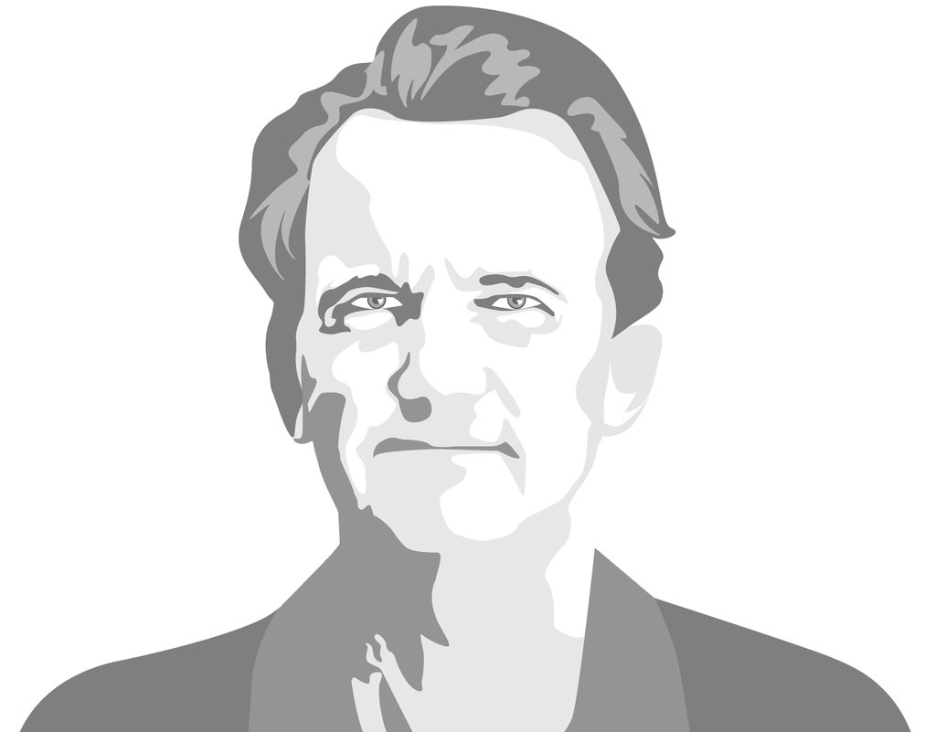

კარგი დიაგრამა იდეას უნდა გადმოსცემდე:

- გარკვევით,
- ზუსტად,
- ეფექტურად

### (მოკლე) შესავალი მონაცემთა ვიზუალიზაციაში

- აჩვენეთ მონაცემები,
- ,,აიძულეთ“ მაყურებელი, იფიქროს მონაცემებზე,
- ნუ დაამახინჯებთ იმას, თუ რას ამბობს მონაცემები,
- წარმოადგინეთ ბევრი მონაცემი მცირე სივრცეში
- იყავით თანმიმდევრული
- წაახალისეთ მაყურებლის თვალი, ერთმანეთს სხვადასხვა კატეგორია შეადაროს
- წარმოადგინეთ მონაცემთა დეტალების სხვადასხვა დონე
- იფიქრეთ, თუ რა არის დიაგრამის მიზანი: აღწერა, აღმოჩენა, ტაბულაცია თუ - დეკორაცია
- დიაგრამა ტექსტთან ინტეგრირებული უნდა იყოს

### (მოკლე) შესავალი მონაცემთა ვიზუალიზაციაში

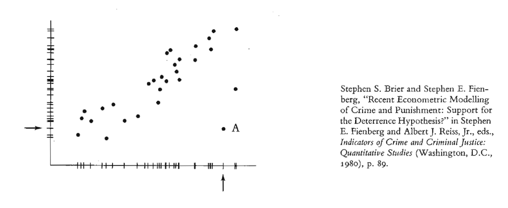

წყარო: VDQI

### (მოკლე) შესავალი მონაცემთა ვიზუალიზაციაში:

- მონაცემების მიერ დიაგრამაზე დაკავებული ფართობი მათი რაოდენობრივი პროპორციების შესატყვისი უნდა იყოს
- მოიშველიეთ წარწერები, რათა დიაგრამაზე არსებული გაურკვევლობები ახსნათ

### (მოკლე) შესავალი მონაცემთა ვიზუალიზაციაში:

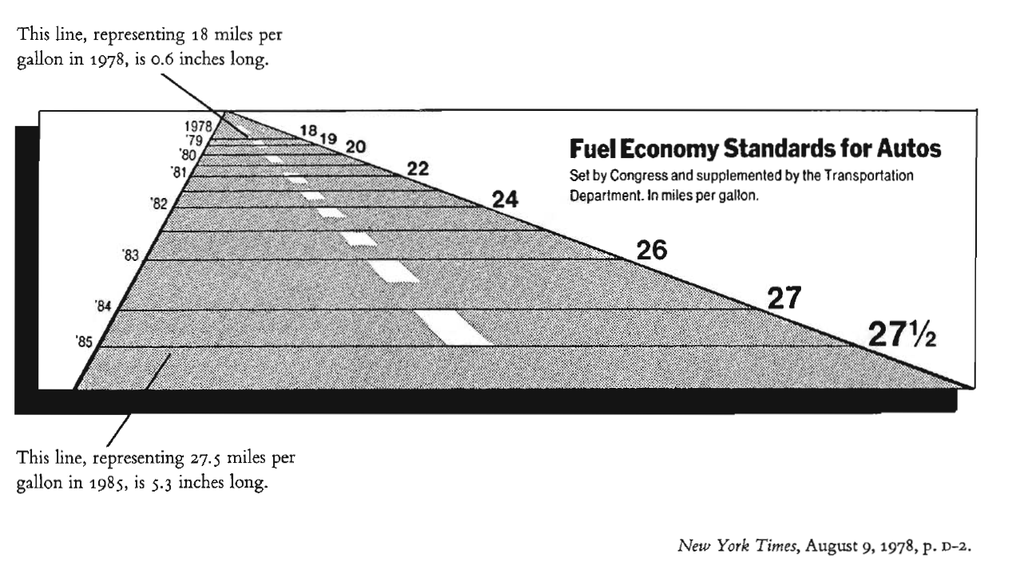

წყარო: VDQI

### (მოკლე) შესავალი მონაცემთა ვიზუალიზაციაში:

- აჩვენეთ მონაცემთა ვარიაცია და არა - დიზაინის ვარიაცია

### (მოკლე) შესავალი მონაცემთა ვიზუალიზაციაში:

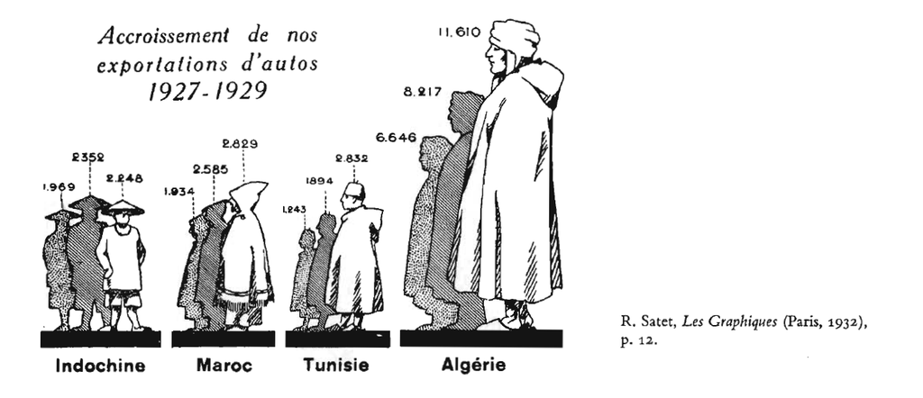

წყარო: VDQI

### (მოკლე) შესავალი მონაცემთა ვიზუალიზაციაში:

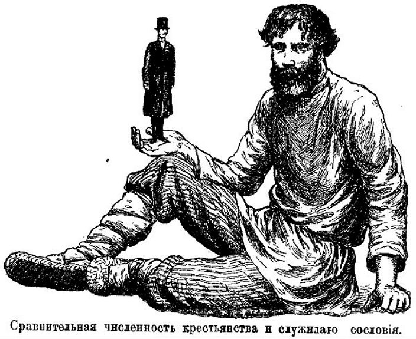

წყარო: VDQI

### (მოკლე) შესავალი მონაცემთა ვიზუალიზაციაში: ტაფტის ხუთი მცნება

- აჩვენეთ მონაცემები,
- გაზარდეთ მონაცემთა და ,,მელნის“ შეფარდება,
- წაშალეთ ის ,,მელანი”, რომელიც მონაცემებიდან არ მომდინარეობს,
- წაშალეთ უსარგებლო ,,მელანი", რომელიც მონაცემებიდან მომდინარეობს,
- გაუკეთეთ რედაქტირება თქვენს ნამუშევარს

### მონაცემთა ,,ფენოვანი" გრამატიკა

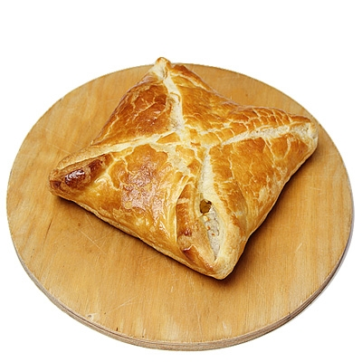

წყარო: [menu.ge](https://www.menu.ge/restaurant/baraka/fenovani-khachapuri_24049.html)

### მონაცემთა ,,ფენოვანი" გრამატიკა (Wilkinson, 2005; Wickham, 2008)

- მონაცემები და ,,ესთეტიკა'';
- ობიექტები (,,გეომები'');
- სტატისტიკური ტრანსფორმაცია (,,სტატები'');
- მასშტაბი;
- წახნაგები (,,ფაცეტები'')

### მონაცემთა ,,ფენოვანი" გრამატიკა: `ggplot2`

```r
p <- ggplot(mtcars)

summary(p)
```

[output not shown]

### მონაცემთა ,,ფენოვანი" გრამატიკა: `ggplot2`

- რა თქმა უნდა, როგორც ყველაფერი, ისე დიაგრამა `ggplot2` გარემოში ობიექტს წარმოადგენს
- ,,ესთეტიკის'' კარტირება ხდება `aes()` ფუნქციის მეშვეობით.
- ,,ესთეტიკა'' აჩვენებს, თუ რა **ცვლადები** უნდა იქნას გამოყენებული დიაგრამაში

### მონაცემთა ,,ფენოვანი" გრამატიკა: `ggplot2`

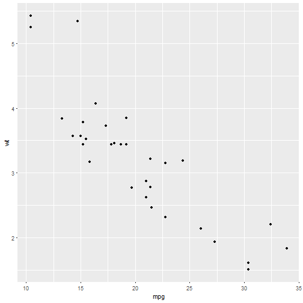

```r
p <- ggplot(mtcars, aes(x=mpg, y=wt))

p + geom_point()
```

### მონაცემთა ,,ფენოვანი" გრამატიკა: `ggplot2`

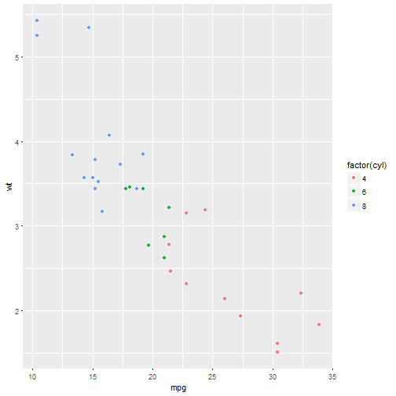

```r
p + geom_point(aes(colour = factor(cyl)))
```

### მონაცემთა ,,ფენოვანი" გრამატიკა: `tidy` მონაცემები (Codd, 1990; Wickham, 2010)

- თითოეული ცვლადი მოცემულია ცალკე სვეტში,
- თითოეული ჩანაწერი მოცემულია ცალკე რიგში,
- ჩანაწერის თითოეული ტიპი ქმნის ცხრილს,

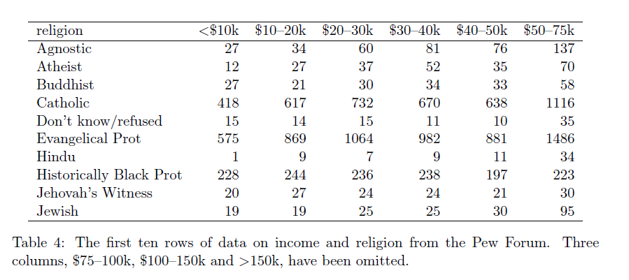

წყარო: Wickham, 2010

### მონაცემთა ,,ფენოვანი" გრამატიკა: `tidy` მონაცემები (Codd, 1990; Wickham, 2010)

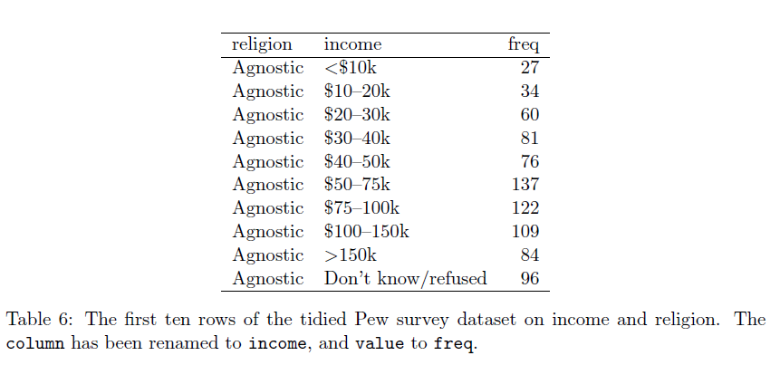

წყარო: Wickham, 2010

### მონაცემთა ,,ფენოვანი" გრამატიკა: ,,ესთეტიკა''

- `position`: პოზიცია,
- `color`: ,,გარეთა ფერი",
- `fill`: ,,შიდა ფერი",
- `shape`: მარკერების ფორმა,
- `linetype`: წრფის ტიპი,
- `size`: ზომა

### მონაცემთა ,,ფენოვანი" გრამატიკა: ,,ესთეტიკა""

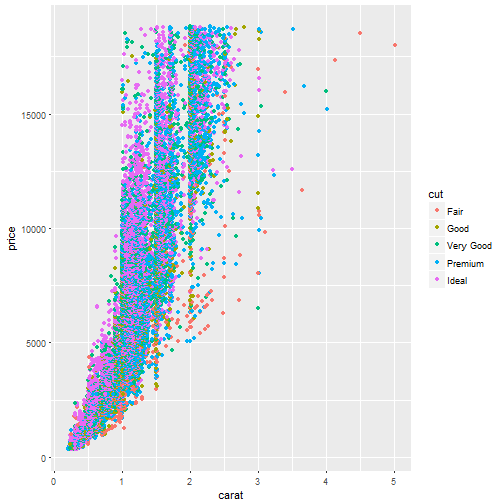

```r
ggplot(diamonds, aes(x=carat, y=price, color=cut)) + geom_point()
```

### მონაცემთა ,,ფენოვანი" გრამატიკა: ,,ესთეტიკა""

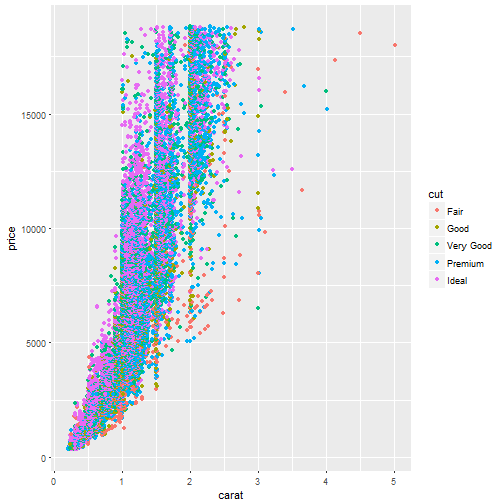

```r
ggplot(diamonds) + geom_point(aes(x=carat, y=price, color=cut))
```

### მონაცემთა ,,ფენოვანი" გრამატიკა: ,,ესთეტიკა""

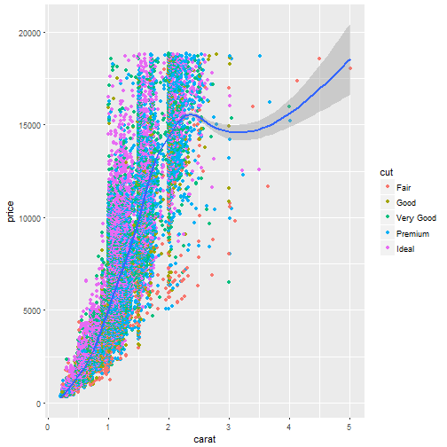

```r
ggplot(diamonds, aes(x=carat, y=price)) + geom_point(aes(color=cut)) + geom_smooth()
```

### მონაცემთა ,,ფენოვანი" გრამატიკა: ,,ესთეტიკა""

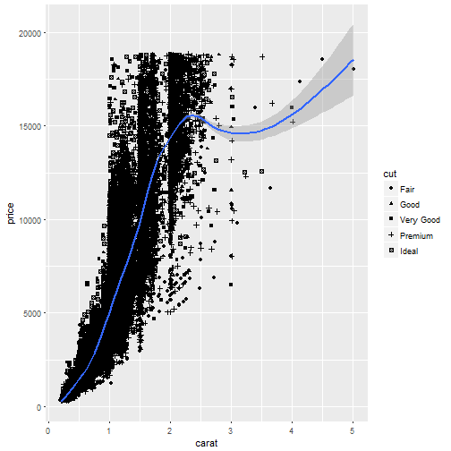

```r
ggplot(diamonds, aes(x=carat, y=price)) + geom_point(aes(shape=cut)) + geom_smooth()
```

### მონაცემთა ,,ფენოვანი" გრამატიკა: ,,გეომები''

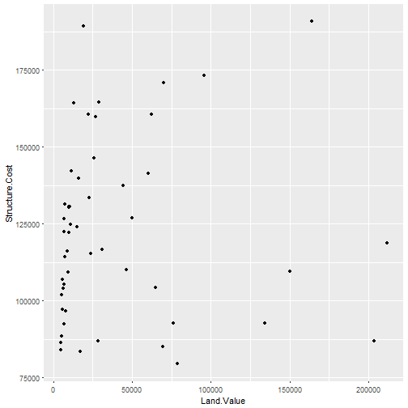

```r
### https://goo.gl/Jrr8LQ

housing <- read.csv("data/landdata-states.csv")

hp2001Q1 <- subset(housing, Date == 2001.25)

ggplot(hp2001Q1, aes(y = Structure.Cost, x = Land.Value)) + geom_point()
```

### მონაცემთა ,,ფენოვანი" გრამატიკა: ,,გეომები''

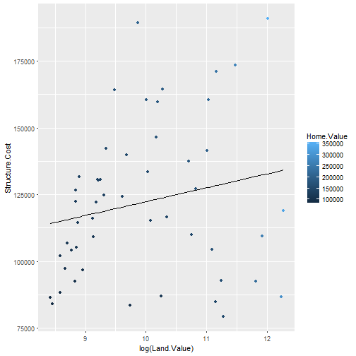

```r
hp2001Q1$pred.SC <- predict(lm(Structure.Cost ~ log(Land.Value), data = hp2001Q1))

p1 <- ggplot(hp2001Q1, aes(x = log(Land.Value), y = Structure.Cost))

p1 + geom_point(aes(color = Home.Value)) + geom_line(aes(y = pred.SC))
```

### მონაცემთა ,,ფენოვანი" გრამატიკა: ,,გეომები''

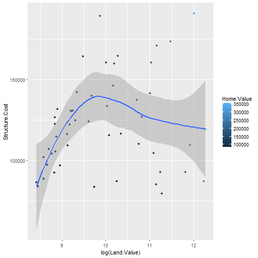

```r
p1 + geom_point(aes(color = Home.Value)) + geom_smooth()
```

### მონაცემთა ,,ფენოვანი" გრამატიკა: ,,გეომები''

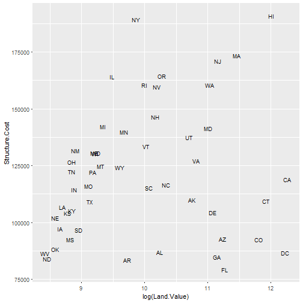

```r
p1 + geom_text(aes(label=State), size = 3)
```

### მონაცემთა ,,ფენოვანი" გრამატიკა: წარწერები

[figure not shown]

```r
gg <- ggplot(diamonds, aes(x=carat, y=price, color=cut)) + geom_point() + labs(title="გაბნევის დიაგრამა :)", x="კარატი", y="ფასი")

print(gg)
```

### მონაცემთა ,,ფენოვანი" გრამატიკა: თემები

[figure not shown]

```r
gg1 <- gg + theme(plot.title=element_text(size=30, face="bold"),
                  axis.text.x=element_text(size=15),
                  axis.text.y=element_text(size=15),
                  axis.title.x=element_text(size=25),
                  axis.title.y=element_text(size=25)) +
  scale_color_discrete(name="ბრილიანტის დამუშავებული ფორმა")
print(gg1)  # print the plot
```

### მონაცემთა ,,ფენოვანი" გრამატიკა: ,,წახნაგები''

[figure not shown]

```r
gg1 + facet_wrap( ~ cut, ncol=3)
```

### მონაცემთა ,,ფენოვანი" გრამატიკა: ,,წახნაგები''

[figure not shown]

```r
gg1 + facet_wrap( ~ cut, ncol=3)
```

### პრაქტიკული სამუშაო

```r
### მონაცემები: https://goo.gl/CuGtsx
```

### სასარგებლო რესურსები:

- `ggplot2` [,,შპარგალკა''](https://www.rstudio.com/wp-content/uploads/2015/03/ggplot2-cheatsheet.pdf)
- [ggplot2: Elegant Graphics for Data Analysis](https://www.amazon.com/ggplot2-Elegant-Graphics-Data-Analysis/dp/331924275X/ref=sr_1_1?s=books&ie=UTF8&qid=1506225102&sr=1-1&keywords=ggplot2)
- [ოფიციალური გვერდი](http://ggplot2.tidyverse.org/index.html)
- რა თქმა უნდა, [Stack Overflow](https://stackoverflow.com/questions/tagged/ggplot2)

### გამოყენებული რესურსები:

Selva Prabhakaran: [How to make any plot in ggplot2?](http://r-statistics.co/ggplot2-Tutorial-With-R.html) Ista Zahn: [R graphics workshop @ Harvard](http://tutorials.iq.harvard.edu/R/Rgraphics/Rgraphics.html)

### გმადლობთ!

[figure not shown]

david@sichinava.ge

[figure not shown]

davidsichinava

[figure not shown]

@davidsichinava